# Project 7: Difference-in-Differences and Synthetic Control

Mahader, Alex, and Kelly

```r
# Install and load packages
if (!require("pacman")) install.packages("pacman")
devtools::install_github("ebenmichael/augsynth")
```

```r
pacman::p_load(# Tidyverse packages including dplyr and ggplot2
               tidyverse,
               ggthemes,
               augsynth,
               gsynth,
               scales)

# set seed
set.seed(1)

# load data
medicaid_expansion <- read.csv('data/medicaid_expansion.csv', sep= ",")
```

# Introduction

For this project, you will explore the question of whether the Affordable Care Act increased health insurance coverage (or conversely, decreased the number of people who are uninsured). The ACA was passed in March 2010, but several of its provisions were phased in over a few years. The ACA instituted the “individual mandate” which required that all Americans must carry health insurance, or else suffer a tax penalty. There are four mechanisms for how the ACA aims to reduce the uninsured population:

- Require companies with more than 50 employees to provide health insurance.
- Build state-run healthcare markets (“exchanges”) for individuals to purchase health insurance.
- Provide subsidies to middle income individuals and families who do not qualify for employer based coverage.
- Expand Medicaid to require that states grant eligibility to all citizens and legal residents earning up to 138% of the federal poverty line. The federal government would initially pay 100% of the costs of this expansion, and over a period of 5 years the burden would shift so the federal government would pay 90% and the states would pay 10%.

In 2012, the Supreme Court heard the landmark case NFIB v. Sebelius, which principally challenged the constitutionality of the law under the theory that Congress could not institute an individual mandate. The Supreme Court ultimately upheld the individual mandate under Congress’s taxation power, but struck down the requirement that states must expand Medicaid as impermissible subordination of the states to the federal government. Subsequently, several states refused to expand Medicaid when the program began on January 1, 2014. This refusal created the “Medicaid coverage gap” where there are indivudals who earn too much to qualify for Medicaid under the old standards, but too little to qualify for the ACA subsidies targeted at middle-income individuals.

States that refused to expand Medicaid principally cited the cost as the primary factor. Critics pointed out however, that the decision not to expand primarily broke down along partisan lines. In the years since the initial expansion, several states have opted into the program, either because of a change in the governing party, or because voters directly approved expansion via a ballot initiative.

You will explore the question of whether Medicaid expansion reduced the uninsured population in the U.S. in the 7 years since it went into effect. To address this question, you will use difference-in-differences estimation, and synthetic control.

# Data

The dataset you will work with has been assembled from a few different sources about Medicaid. The key variables are:

- **State**: Full name of state
- **Medicaid Expansion Adoption**: Date that the state adopted the Medicaid expansion, if it did so.
- **Year**: Year of observation.
- **Uninsured rate**: State uninsured rate in that year.

# Exploratory Data Analysis

Create plots and provide 1-2 sentence analyses to answer the following questions:

- Which states had the highest uninsured rates prior to 2014? The lowest?
- Which states were home to most uninsured Americans prior to 2014? How about in 2021? **Note**: 2010 state population is provided as a variable to answer this question. In an actual study you would likely use population estimates over time, but to simplify you can assume these numbers stay about the same.

```r
summary(medicaid_expansion)
```

```
##     State           Date_Adopted            year      uninsured_rate
##  Length:663         Length:663         Min.   :2008   Min.   :0.02495
##  Class :character   Class :character   1st Qu.:2011   1st Qu.:0.07702
##  Mode  :character   Mode  :character   Median :2014   Median :0.10475
##                                        Mean   :2014   Mean   :0.10978
##                                        3rd Qu.:2017   3rd Qu.:0.13888
##                                        Max.   :2020   Max.   :0.24082
##
##    population
##  Min.   :  584153
##  1st Qu.: 1850326
##  Median : 4531566
##  Mean   : 6364343
##  3rd Qu.: 7061530
##  Max.   :38802500
##  NA's   :13
```

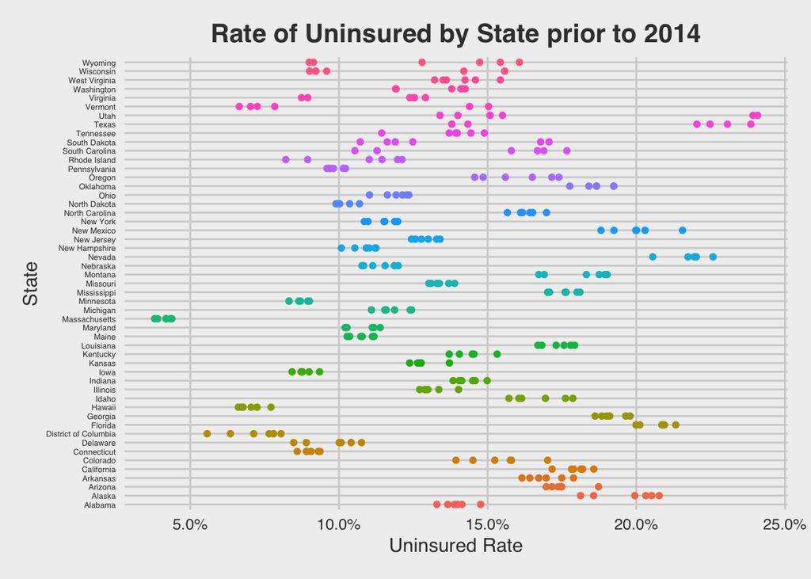

```r
# highest and lowest uninsured rates

high_low <-
  medicaid_expansion[order(-medicaid_expansion$uninsured_rate),] %>%
  filter(year < 2014)

high_low %>%
  ggplot(aes(x = uninsured_rate, y = State, color = State)) +
  geom_point() +
  ggtitle('Rate of Uninsured by State prior to 2014') +
  scale_x_continuous('Uninsured Rate', labels = percent) +
  scale_y_discrete('State') +
  theme_fivethirtyeight() +
  theme(plot.title = element_text(size = 16, hjust = 0.5),
        axis.title = element_text(size = 12),
        axis.text.y = element_text(size = 5),
        legend.position = 'None')
```

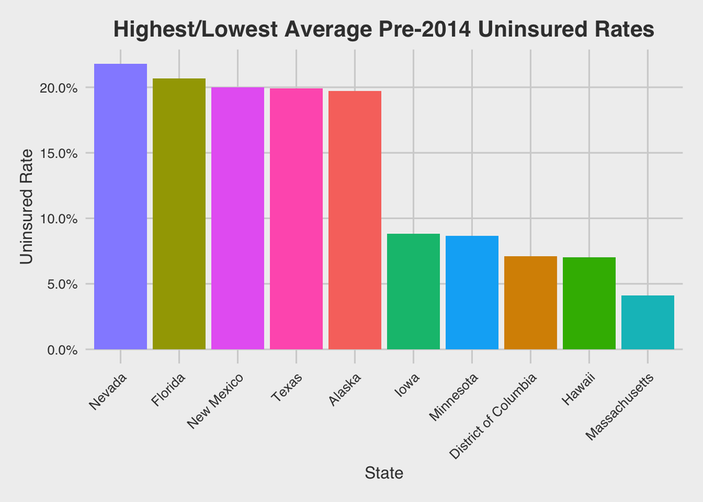

```r
## States with 5 highest and lowest average pre-2014 uninsured rates
high_low %>%
  group_by(State) %>%
  summarize(mean_uninsured_rate = mean(uninsured_rate)) %>%
  arrange(mean_uninsured_rate) %>%
  slice(c(1:5, 47:51)) %>%
  ggplot(aes(x = reorder(State, -mean_uninsured_rate), y = mean_uninsured_rate, fill = State)) +
  geom_col() +
  ggtitle('Highest/Lowest Average Pre-2014 Uninsured Rates') +
  scale_y_continuous('Uninsured Rate', labels = percent) +
  scale_x_discrete('State') +
  theme_fivethirtyeight() +
  theme(plot.title = element_text(size = 16, hjust = 0.5),
        axis.title = element_text(size = 12),
        axis.text.x = element_text(hjust = 1, angle = 45),
        legend.position = 'None')
```

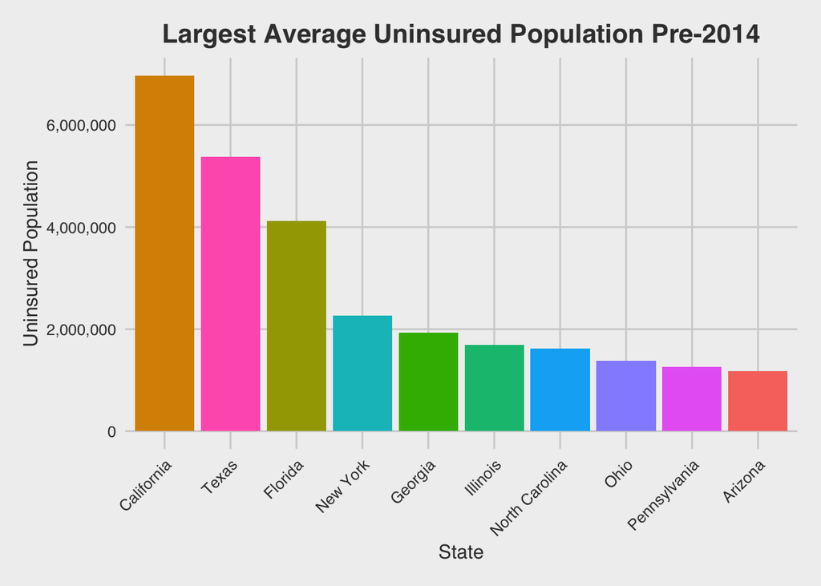

```r
high_low %>%
  mutate(uninsured = uninsured_rate*population) %>%
  group_by(State) %>%
  summarize(mean_uninsured = mean(uninsured)) %>%
  arrange(desc(mean_uninsured)) %>%
  slice(1:10) %>%
  ggplot(aes(x = reorder(State, -mean_uninsured), y = mean_uninsured, fill = State)) +
  geom_col() +
  ggtitle('Largest Average Uninsured Population Pre-2014') +
  scale_y_continuous('Uninsured Population', labels = comma) +
  scale_x_discrete('State') +
  theme_fivethirtyeight() +
  theme(plot.title = element_text(size = 16, hjust = 0.5),
        axis.title = element_text(size = 12),
        axis.text.x = element_text(hjust = 1, angle = 45),
        legend.position = 'None')
```

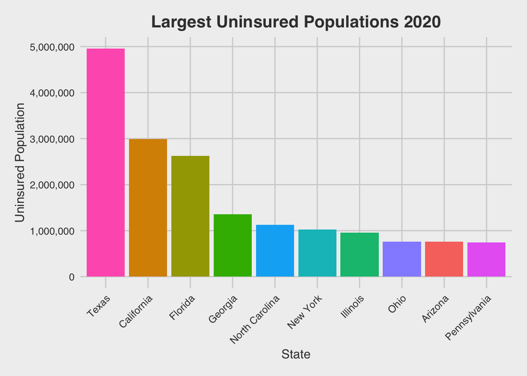

```r
## 2020 largest uninsured population
medicaid_expansion %>%
  filter(year == 2020) %>%
  mutate(uninsured = uninsured_rate*population) %>%
  arrange(desc(uninsured)) %>%
  slice(1:10) %>%
  ggplot(aes(x = reorder(State, -uninsured), y = uninsured, fill = State)) +
  geom_col() +
  ggtitle('Largest Uninsured Populations 2020') +
  scale_y_continuous('Uninsured Population', labels = comma) +
  scale_x_discrete('State') +
  theme_fivethirtyeight() +
  theme(plot.title = element_text(size = 16, hjust = 0.5),
        axis.title = element_text(size = 12),
        axis.text.x = element_text(hjust = 1, angle = 45),
        legend.position = 'None')
```

Examining the actual populations that were uninsured during the pre-2014 time period, California, Texas, and Florida top the list due to a combination of their relatively large populations and high uninsurance rates. While Texas and Florida had among the highest average uninsured rates, California had the largest uninsured population due to its sheer population size. While the same 10 states had the largest uninsured populations in the pre-2014 period and in 2020 as a function of their large populations, California notably cut its uninsured population by more than 50%. The relatively stable size of Texas’ uninsured population, on the other hand, gave it by far the largest uninsured population in 2020.

# Difference-in-Differences Estimation

## Estimate Model

Do the following:

- Choose a state that adopted the Medicaid expansion on January 1, 2014 and a state that did not. **Hint**: Do not pick Massachusetts as it passed a universal healthcare law in 2006, and also avoid picking a state that adopted the Medicaid expansion between 2014 and 2015.
- Assess the parallel trends assumption for your choices using a plot. If you are not satisfied that the assumption has been met, pick another state and try again (but detail the states you tried).

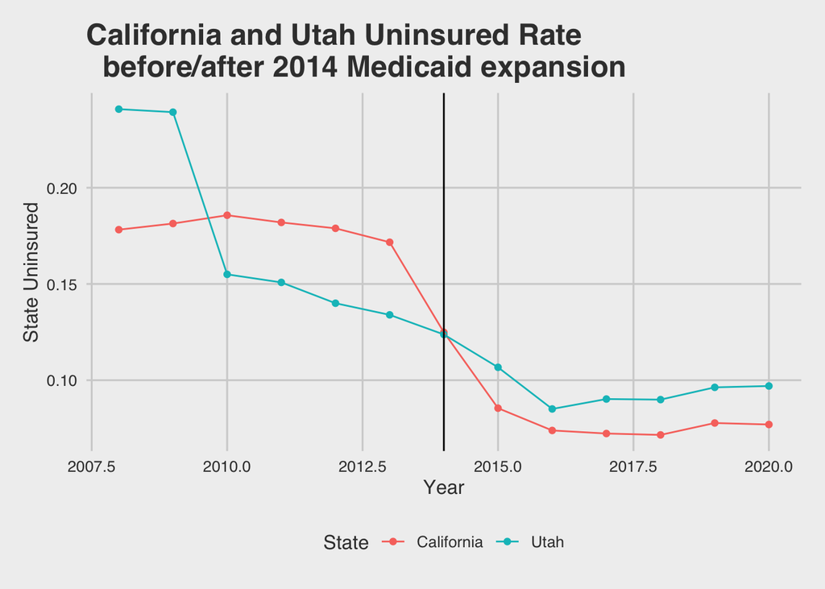

```r
# Parallel Trends plot

#California as state adopted 1/1/2014
#Utah as state that didnt adopt until 1/1/2020

medicaid_expansion %>%
  filter(State %in% c("California", "Utah")) %>%
  ggplot() +
  geom_point(aes(x = year,
                 y = uninsured_rate,
                 color = State)) +
  geom_line(aes(x = year,
                y = uninsured_rate,
                color = State)) +
  geom_vline(aes(xintercept = 2014)) +
  theme_fivethirtyeight() +
  theme(axis.title = element_text()) +
  ggtitle('California and Utah Uninsured Rate \n  before/after 2014 Medicaid expansion') +
  xlab('Year') +
  ylab('State Uninsured')
```

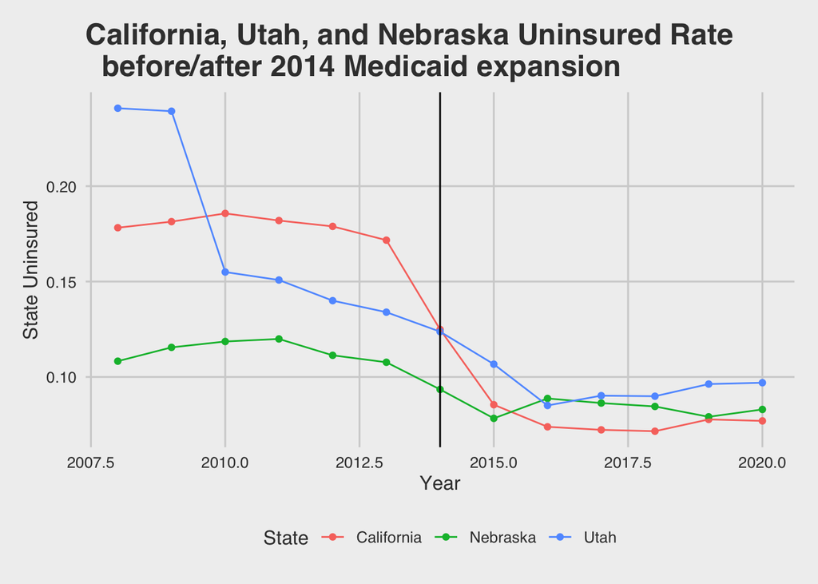

```r
# the two states do not move in parallel pre-2014; will pick Nebraska (didn't adopt until 1/10/2020) and see what happens

medicaid_expansion %>%
  filter(State %in% c("California", "Utah", "Nebraska")) %>%
  ggplot() +
  geom_point(aes(x = year,
                 y = uninsured_rate,
                 color = State)) +
  geom_line(aes(x = year,
                y = uninsured_rate,
                color = State)) +
  geom_vline(aes(xintercept = 2014)) +
  theme_fivethirtyeight() +
  theme(axis.title = element_text()) +
  ggtitle('California, Utah, and Nebraska Uninsured Rate \n  before/after 2014 Medicaid expansion') +
  xlab('Year') +
  ylab('State Uninsured')
```

- Estimates a difference-in-differences estimate of the effect of the Medicaid expansion on the uninsured share of the population. You may follow the lab example where we estimate the differences in one pre-treatment and one post-treatment period, or take an average of the pre-treatment and post-treatment outcomes

```r
# Difference-in-Differences estimation

# pre-treatment difference
pre_diff <- medicaid_expansion %>%
  filter(State %in% c("California","Nebraska")) %>%
  filter(year == 2013) %>%
  select(State,
         uninsured_rate) %>%
  spread(State,
         uninsured_rate) %>%
  summarise(California - Nebraska)

# post-treatment difference
post_diff <- medicaid_expansion %>%
  filter(State %in% c("California","Nebraska")) %>%
  filter(year == 2015) %>%
  select(State,
         uninsured_rate) %>%
  spread(State,
         uninsured_rate) %>%
  summarise(California - Nebraska)

# diff-in-diffs
diff_in_diffs <- post_diff - pre_diff
diff_in_diffs
```

```
##   California - Nebraska
## 1              -0.05682
```

## Discussion Questions

- Card/Krueger’s original piece utilized the fact that towns on either side of the Delaware river are likely to be quite similar to one another in terms of demographics, economics, etc. Why is that intuition harder to replicate with this data?
- **Answer**: There is likely a lot of heterogeneity between the states in terms of demographics, SES, other covariates. This would violate our parallel trends assumption. Essentially we want to make the change in the uninsured rate in the control group (here Nebraska) to be a good proxy for the counterfactual change in uninsured rate in our treatment group (here California) had they not been treated (i.e expanded Medicaid). This is less likely to be the case if there are a variety of factors that make the two states different.
- What are the strengths and weaknesses of using the parallel trends assumption in difference-in-differences estimates?
- **Answer**:

Pros: - Easily interpretable - The assumption allows you to use just one pre- and one post-treatment period - You are able to use smaller time periods where difference between treatment and control groups are constant

Cons: - There is no statistical test for this assumption - Is less likely to hold with longer time periods - Violation of this assumption will lead to biased estimates

# Synthetic Control

Estimate Synthetic Control

Although several states did not expand Medicaid on January 1, 2014, many did later on. In some cases, a Democratic governor was elected and pushed for a state budget that included the Medicaid expansion, whereas in others voters approved expansion via a ballot initiative. The 2018 election was a watershed moment where several Republican-leaning states elected Democratic governors and approved Medicaid expansion. In cases with a ballot initiative, the state legislature and governor still must implement the results via legislation. For instance, Idaho voters approved a Medicaid expansion in the 2018 election, but it was not implemented in the state budget until late 2019, with enrollment beginning in 2020.

Do the following:

- Choose a state that adopted the Medicaid expansion after January 1, 2014. Construct a non-augmented synthetic control and plot the results (both pre-treatment fit and post-treatment differences). Also report the average ATT and L2 imbalance.

First, we identify states that adopted the medicaid expansion after 2014; then, we create a donor pool of states that were never treated for our synthetic control.

```r
#identify states that adopted medicaid expansion after 1/1/2014
medicaid_expansion %>%
  filter(lubridate::year(Date_Adopted) > 2014) %>%
  select(State, Date_Adopted) %>%
  unique()
```

```
##          State Date_Adopted
## 1       Alaska   2015-09-01
## 2        Idaho   2020-01-01
## 3      Indiana   2015-02-01
## 4    Louisiana   2016-07-01
## 5      Montana   2016-01-01
## 6     Nebraska   2020-10-01
## 7 Pennsylvania   2015-01-01
## 8         Utah   2020-01-01
## 9     Virginia   2019-01-01
```

```r
# select states that never adopted for donor pool
donor_pool <- medicaid_expansion %>%
  filter(is.na(Date_Adopted)) %>%
  select(State) %>%
  unique()
```

Now, we create a synthetic control for Pennsylvania from the donor pool.

```r
# non-augmented synthetic control

medicaid_expansion %>% select(State, Date_Adopted) %>% unique() %>% count() # check no duplicated values for date adopted, good
```

```
##    n
## 1 51
```

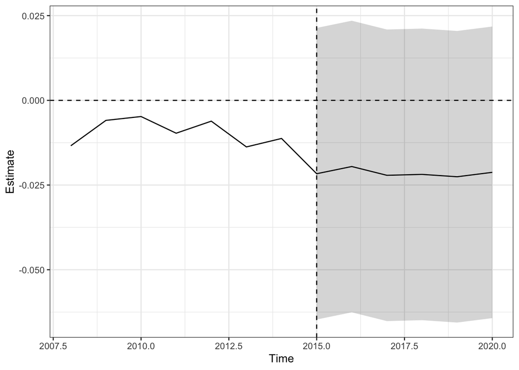

```r
# first create treatment flag for whether medicaid expansion had happened at time of obs -- not sure how to think about mid year adoptions
delayed_adoption <- medicaid_expansion %>%
  filter(State=="Pennsylvania"|State %in% donor_pool$State) %>%
  mutate(Treatment = ifelse(lubridate::year(Date_Adopted) > year | is.na(Date_Adopted), 0, 1))


syn <- augsynth(form = uninsured_rate ~ Treatment,
                unit = State,
                time = year,
                data = delayed_adoption,
                t_int = 2015,
                progfunc = "None", # no augment
                scm = T)

syn_summary <- summary(syn)

# save the l2 imbalance and ATT estimates, rounding to report out
syn_L2 <- syn_summary[["l2_imbalance"]] %>% round(4)
syn_ATT <- syn_summary[["average_att"]][["Estimate"]] %>% round(4)

plot(syn)
```

```r
# synthetic pennsylvania underestimating pennsylvania outcome before treatment, and estimate gets worse right before treatment
```

The L2 imbalance for non-augmented synthetic control is 0.0262; the average treatment on the treated is -0.0215.

Look at weights for contributing states: almost entirely coming from Maine with a tiny fraction from Wisconsin.

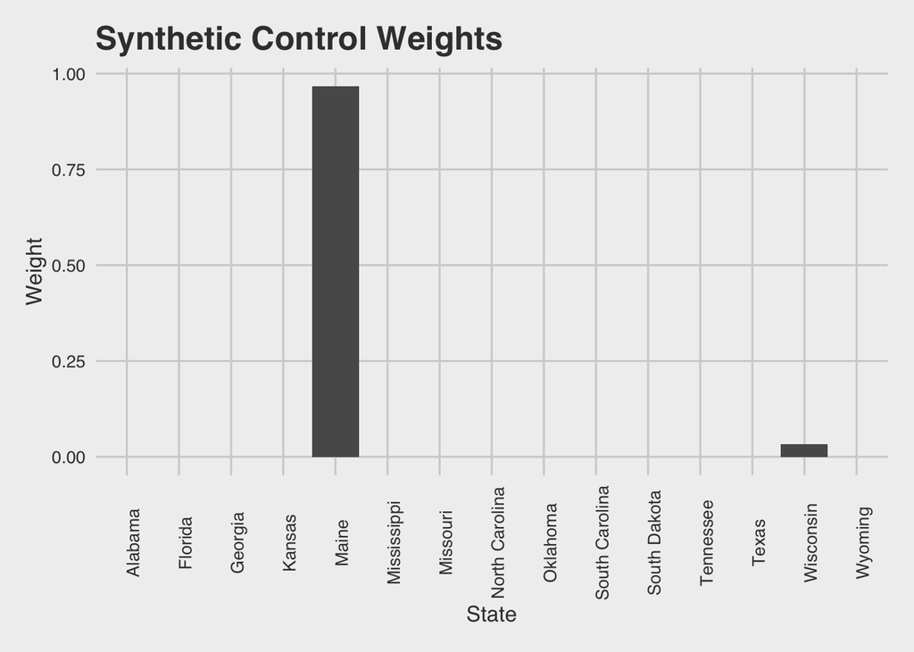

```r
# Convert weights to dataframe
data.frame(syn$weights) %>%
  # change index to a column
  tibble::rownames_to_column('State') %>%
  ggplot() +
  # stat = identity to take the literal value instead of a count for geom_bar()
  geom_bar(aes(x = State,
               y = syn.weights),
           stat = 'identity') +
  theme_fivethirtyeight() +
  theme(axis.title = element_text(),
        axis.text.x = element_text(angle = 90)) +
  ggtitle('Synthetic Control Weights') +
  xlab('State') +
  ylab('Weight')
```

- Re-run the same analysis but this time use an augmentation (default choices are Ridge, Matrix Completion, and GSynth). Create the same plot and report the average ATT and L2 imbalance.

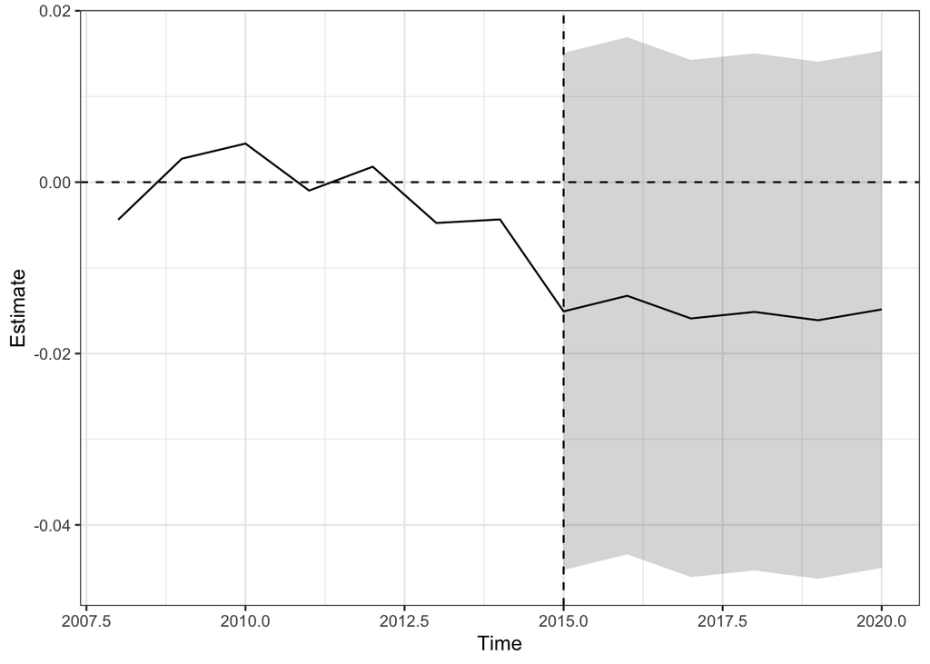

```r
# augmented synthetic control
augsyn <- augsynth(form = uninsured_rate ~ Treatment,
                unit = State,
                time = year,
                data = delayed_adoption,
                t_int = 2015,
                progfunc = "Ridge", # ridge
                scm = T)

augsyn_summary <- summary(augsyn)

# save the l2 imbalance and ATT estimates, rounding to report out
augsyn_L2 <- augsyn_summary[["l2_imbalance"]] %>% round(4)
augsyn_ATT <- augsyn_summary[["average_att"]][["Estimate"]] %>% round(4)

plot(augsyn)
```

The L2 imbalance for augmented synthetic control is 0.0096; the average treatment on the treated is -0.0151. There is substantially better balance with oour augmented synthetic control, and the ATT, while still negative, is now smaller in magnitude.

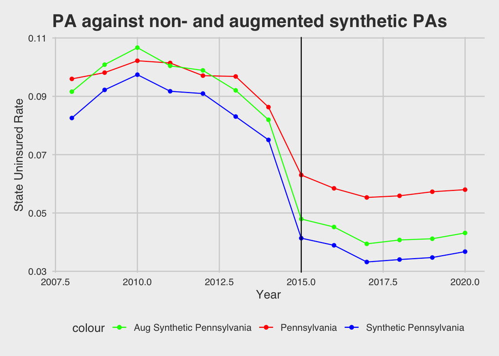

```r
# add difference between synthetic pennsylvania and pennsylvania to obtain estimate
penn_synpenn <- medicaid_expansion %>%
  filter(State == "Pennsylvania") %>%
  bind_cols(difference = syn_summary$att$Estimate,
            augdifference = augsyn_summary$att$Estimate) %>%
  mutate(synthetic_pennsylvania = uninsured_rate + difference,
         augsynthetic_pennsylvania = uninsured_rate + augdifference)

# Plot

penn_synpenn %>%
  ggplot() +
  geom_point(aes(x = year,
                 y = uninsured_rate,
                 color = 'Pennsylvania')) +
  geom_line(aes(x = year,
                y = uninsured_rate,
                color = 'Pennsylvania')) +
  geom_point(aes(x = year,
                 y = synthetic_pennsylvania,
                 color = 'Synthetic Pennsylvania')) +
  geom_line(aes(x = year,
                y = synthetic_pennsylvania,
                color = 'Synthetic Pennsylvania')) +
  geom_point(aes(x = year,
                 y = augsynthetic_pennsylvania,
                 color = 'Aug Synthetic Pennsylvania')) +
  geom_line(aes(x = year,
                y = augsynthetic_pennsylvania,
                color = 'Aug Synthetic Pennsylvania')) +
  scale_color_manual(values = c('Pennsylvania' = 'red', 'Synthetic Pennsylvania' = 'blue', 'Aug Synthetic Pennsylvania' = 'green')) +
  geom_vline(aes(xintercept = 2015)) +
  theme_fivethirtyeight() +
  theme(axis.title = element_text()) +
  ggtitle('PA against non- and augmented synthetic PAs') +
  xlab('Year') +
  ylab('State Uninsured Rate')
```

As captured in the L2 imbalance and in this graph, the augmented synthetic control aligns more closely with Pennsylvania than the non-augmented synthetic control.

- Plot barplots to visualize the weights of the donors.

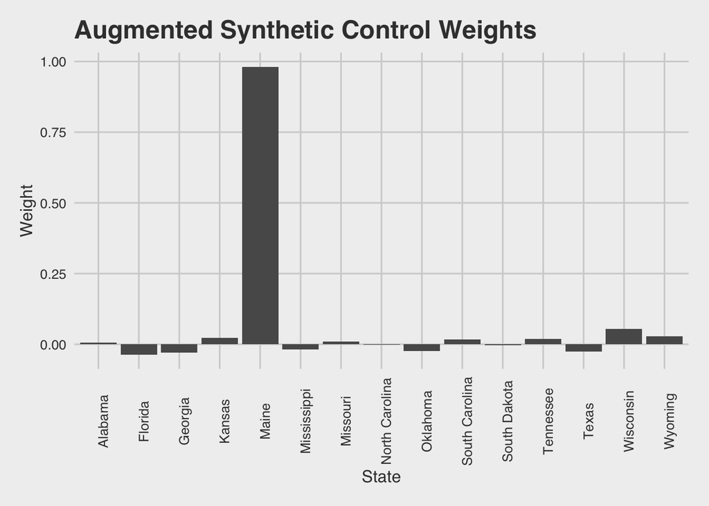

```r
# barplots of weights
# Convert weights to dataframe
data.frame(augsyn$weights) %>%
  # change index to a column
  tibble::rownames_to_column('State') %>%
  ggplot() +
  # stat = identity to take the literal value instead of a count for geom_bar()
  geom_bar(aes(x = State,
               y = augsyn.weights),
           stat = 'identity') +
  theme_fivethirtyeight() +
  theme(axis.title = element_text(),
        axis.text.x = element_text(angle = 90)) +
  ggtitle('Augmented Synthetic Control Weights') +
  xlab('State') +
  ylab('Weight')
```

While Maine is still the largest donor, a few more states are positively weighted with Florida, Georgia, Mississippi, Oklahoma, and Texas now being negatively weighted.

**HINT**: Is there any preprocessing you need to do before you allow the program to automatically find weights for donor states? Yes—we need to limit the donor pool to those states that were never treated in any time period, even post treatment. One limitation here is that those states who never implemented the medicaid expansion might be contextually different than those that did.

## Discussion Questions

- What are the advantages and disadvantages of synthetic control compared to difference-in-differences estimators?
- **Answer**: As mentioned above, the simplicity of difference-in-differences makes it easily interpretable, but comes at a cost of only being able to compare two units. While slightly more complicated to interpret, synthetic control allows us to draw from multiple comparison units to create a counterfactual that may more closely align with the pre-treatment outcome trends of the treated unit, as we saw above in question 4 where it was difficult to find a good match for our selected treated state (California). Drawing from multiple comparison units also spreads the risk of post-treatment confounding across multiple units, rather than rely on there being none in our singular control unit with difference-in-differences.
- One of the benefits of synthetic control is that the weights are bounded between [0,1] and the weights must sum to 1. Augmentation might relax this assumption by allowing for negative weights. Does this create an interpretation problem, and how should we balance this consideration against the improvements augmentation offers in terms of imbalance in the pre-treatment period?
- **Answer**: Having negative weights makes understanding how the comparison outcomes are constructed a bit more challenging but doesn’t change how we interpret the results. As we can see, the augmented synthetic control outcomes align more closely pre-treatment with Pennsylvania’s uninsured rate than the non-augmented outcomes do. While adding more complexity might result in overfitting, regularization mitigates this concern. Overall, it might not be worth the interpretation trade-off to use augmented synthetic controls where synthetic controls do a good job predicting pre-treatment outcomes, but may be a viable alternative when they provide a substantial improvement over non-augmented synthetic controls.

# Staggered Adoption Synthetic Control

## Estimate Multisynth

Do the following:

- Estimate a multisynth model that treats each state individually. Choose a fraction of states that you can fit on a plot and examine their treatment effects.

```r
# add permanent year/treatment fields
medicaid_expansion <- medicaid_expansion %>%
  mutate(Year_Adopted = substr(Date_Adopted, 1, 4),
         Year_Adopted = ifelse(is.na(Year_Adopted), Inf, Year_Adopted),
         treatment = 1 * (year >= Year_Adopted))
```

```r
# with a choice of nu
sa_syn <- multisynth(uninsured_rate ~ treatment, State, year,
                     medicaid_expansion, nu = 0, n_leads = 7)

sa_syn_summ <- summary(sa_syn)

sa_syn
```

```
##
## Call:
## multisynth(form = uninsured_rate ~ treatment, unit = State, time = year,
##     data = medicaid_expansion, n_leads = 7, nu = 0)
##
## Average ATT Estimate: -0.016
```

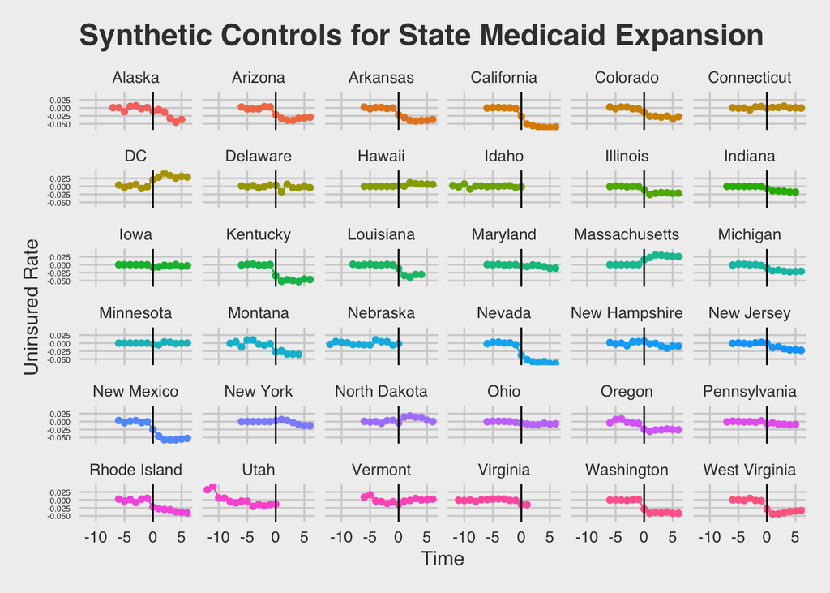

```r
sa_syn_summ$att %>%
  mutate(Level = ifelse(Level == "District of Columbia", "DC", Level)) %>%
  filter(Level != "Average") %>%
  ggplot(aes(x = Time, y = Estimate, color = Level)) +
  geom_point() +
  geom_line() +
  geom_vline(xintercept = 0) +
  scale_y_continuous(breaks = seq(-0.05, 0.025, 0.025)) +
  theme_fivethirtyeight() +
  theme(axis.title = element_text(),
        axis.text.y = element_text(size = 5),
        legend.position = 'None') +
  ggtitle('Synthetic Controls for State Medicaid Expansion') +
  xlab('Time') +
  ylab('Uninsured Rate') +
  facet_wrap(~Level)
```

- Estimate a multisynth model using time cohorts. For the purpose of this exercise, you can simplify the treatment time so that states that adopted Medicaid expansion within the same year (i.e. all states that adopted epxansion in 2016) count for the same cohort. Plot the treatment effects for these time cohorts.

```r
sa_tc_syn <- multisynth(uninsured_rate ~ treatment, State, year,
                     medicaid_expansion, n_leads = 7, time_cohort = TRUE)

sa_tc_syn_summ <- summary(sa_tc_syn)

sa_tc_syn
```

```
##
## Call:
## multisynth(form = uninsured_rate ~ treatment, unit = State, time = year,
##     data = medicaid_expansion, n_leads = 7, time_cohort = TRUE)
##
## Average ATT Estimate: -0.016
```

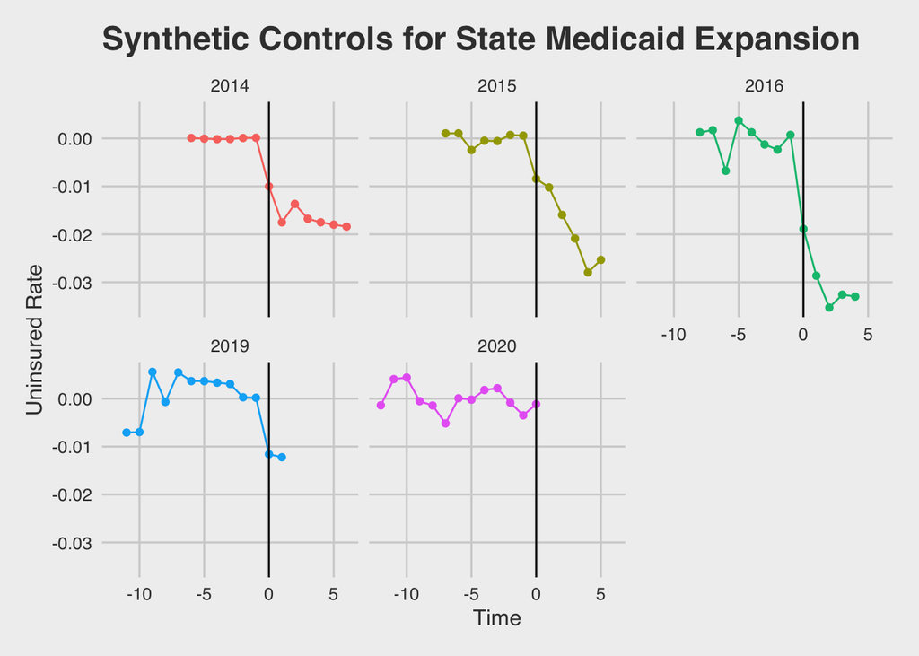

```r
sa_tc_syn_summ$att %>%
  filter(Level != "Average") %>%
  ggplot(aes(x = Time, y = Estimate, color = Level)) +
  geom_point() +
  geom_line() +
  geom_vline(xintercept = 0) +
  theme_fivethirtyeight() +
  theme(axis.title = element_text(),
        legend.position = 'None') +
  ggtitle('Synthetic Controls for State Medicaid Expansion') +
  xlab('Time') +
  ylab('Uninsured Rate') +
  facet_wrap(~Level)
```

## Discussion Questions

# General Discussion Questions

- Why are DiD and synthetic control estimates well suited to studies of aggregated units like cities, states, countries, etc?
- **Answer**: These methods allow us to look at aggregate level exposures (e.g. city exposed to an event/policy change) and compare differences in outcome due to that exposure. They also allow us to measure these aggregate events (e.g. policy intervention) that are often infrequent, which is not easily done via traditional regression analysis (which often requires large sample sizes and multiple observations for estimating effects of a treatment/intervention).
- What role does selection into treatment play in DiD/synthetic control versus regression discontinuity? When would we want to use either method?
- **Answer**: We would want to use DiD when we can make the assumption that the difference between our groups of comparison is constant over time. In other words, we assume that the trends in our outcome of interest would be the same for each group in the absence of treatment. Additionally, selection into treatment is often defined by whether such a group was exposed to some aggregate event while another group was not/other groups were not (e.g. tobacco policy enacted in California but not in other states). In regression discontinuity, on the other hand, a cutoff/threshold is assigned and groups are assigned to treatment or control groups based solely on this cutoff score (ie. selection into treatment is based on a cutoff value). It might make sense to use this kind of analysis if you are trying to target a certain treatment to a select group of people (e.g. treatment to the most ill patients). The assumption with regression discontinuity design is that the observations just below and above the cutoff/threshold are relatively comparable.